# Probabilidade

Marcelo

06/04/2021

# Probabilidade

- Medir a incerteza
- Valor numérico entre 0 e 1
- *Probabilidade* a medida da *possibilidade* de um evento ocorrer
  - Há 60% de *probabilidade* de chuva amanhã
  - Há mais *possibilidade* de que chove do que não chova

## Experimento

- Medir ou observar uma atividade com o objetivo de coletar dados

## Espaço amostral

- Todos os resultados possíveis

## Evento

- Um ou mais resultados de um experimento

## Probabilidade clássica

- Usada quando sabemos o número de possíveis resultados
  - *P(A) = S/N*

## Probabilidade empírica

- Quando não sabemos os possíveis resultados
  - *P(A) = Frequencia do evento A / Número de observações*
- Supondo que 100 pessoas entraram na loja e 15 compraram
  - *P(A) = 15/100*

## Probabilidade empírica

- Quando não da para usar probabilidade clássica e empírica
- Usamos o julgamento

## Tipo de distribuição

- Objetivo - associar uma probabilidade a cada resultado numérico
- Pode ser discreta ou continua

## Distribuição binominal

- *Para variáveis discretas*
- Quando o experimento apresenta sucesso ou fracasso
- O cliente que entrou na loja que adquiriu um plano ?
  - Resposta sim ou não
  - Probabilidade de sucesso - p = 1 - q
  - observações são indepententes
  - A Média de uma Distribuição Binomial, representa a média de longo prazo de sucessos esperados, baseado no número de observações.
- A Variância de uma Distribuição Binomial, representa a variação que existe no número de sucessos (p) sobre um número (n) de observações.

```r
# Para este exemplo, vamos chamar um sucesso um ataque fatal (p = 0.04).
# Temos n = 5 pacientes e queremos saber a probabilidade de que todos sobrevivam ou, em outras palavras,
# que nenhum seja fatal (0 sucessos).

# X = Número de sobreviventes ao ataque
# p = 0.04
# n = 5
# dbinom(X, n, p)
?dbinom
a <- dbinom(0, 5, 0.04)
print(a)
```

```
## [1] 0.8153727
```

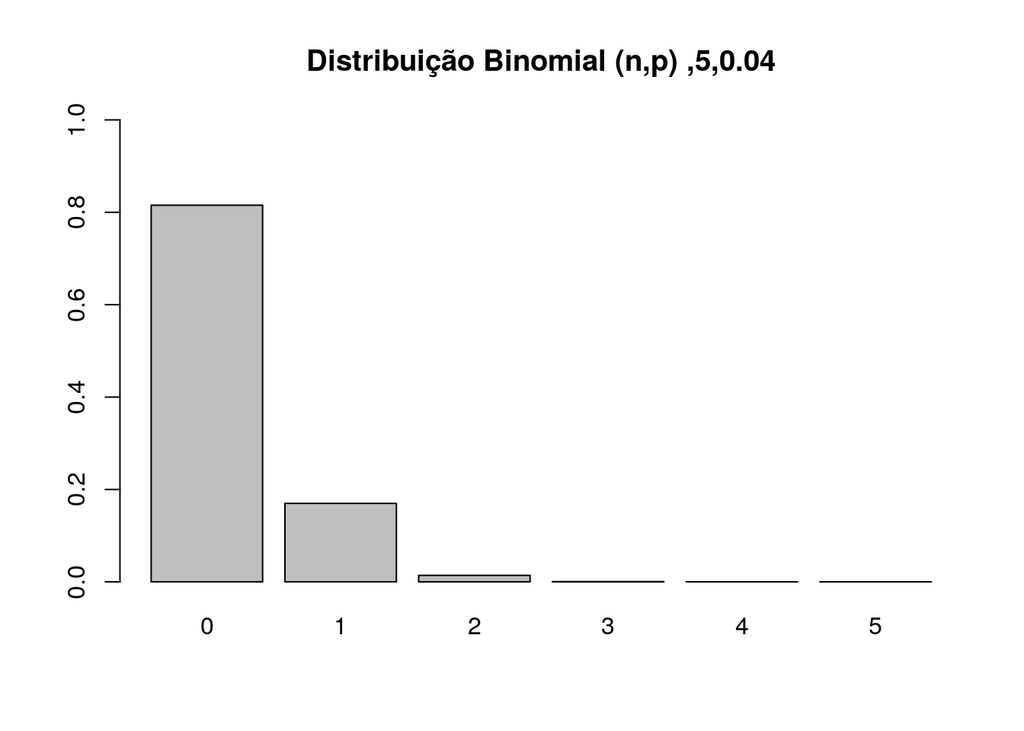

```r
# Desenhando a distribuição de probabilidades
graph <- function(n,p){
  x <- dbinom(0:n, size = n, prob = p)
  barplot(x,ylim=c(0,1),names.arg=0:n,
          main=sprintf(paste('Distribuição Binomial (n,p) ',n,p,sep=',')))
}
graph(5,0.04)
```

## Distribuição Poison

- *Para variáveis discretas*
- Calcular certo númeto de eventos em um intervalo de tempo e espaço
- Quantidade de clientes que entrará na próxima hora
- Dado que a taxa de eventos por unidade é constante e os eventos ocorrem de modo independente.

```r
# Exemplo: Considere um processo que têm uma taxa de 0,5 defeitos por unidade.
# Qual a probabilidade de uma unidade apresentar dois defeitos? E nenhum defeito?
?dpois
dpois(2, 0.5)
```

```
## [1] 0.07581633
```

```r
dpois(0, 0.5)
```

```
## [1] 0.6065307
```

## Distribuição Contínuas

- Distribuição *normal*
  - Quando os dados tendem a estar próximas do centro
- Distribuição *exponencial*
  - Quando temos desprooporção entre os dados
- Distribuição *uniforme*
  - Descreve dados com as mesmas chances de ocorrer

## Distribuição normal

- A Distribuição Normal, ou Gaussiana, é a mais importante distribuição contínua.
- Isso por conta de vários fatores, entre eles, o teorema central do limite, o qual é um resultado essencial
- em aplicações práticas e teóricas, pois garante que, mesmo que os dados não sejam distribuídos segundo uma normal
- A média dos dados converge para uma distribuição normal conforme o número de dados aumenta.
- O R inclui funcionalidades para operações com distribuições de probabilidades.
- Para cada distribuição há 4 operações básicas indicadas pelas letras:
- d: calcula a densidade de probabilidade f(x) no ponto
- p: calcula a função de probabilidade acumulada F(x) no ponto
- q: calcula o quantil correspondente a uma dada probabilidade
- r: retira uma amostra da distribuição
- Para utlizar as funções combina-se uma das letras acima com uma abreviatura do nome da distribuição.
- Por exemplo, para calcular probabilidades usamos: pnorm para normal, pexp para exponencial,
- pbinom para binomial, ppois para Poisson e assim por diante.
- x <- rnorm(n, mean, sd)
- Onde n é o tamanho da amostra e mean e sd são parâmetros opcionais relacionados à média e desvio padrão,
- respectivamente.

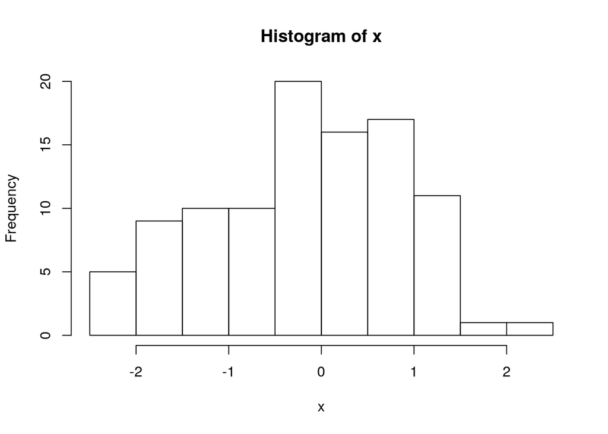

```r
x <- rnorm(100)
hist(x)
```

- Densidade
  - Observe que o gráfico gerado assemelha-se a uma Gaussiana e não apresenta assimentria.
  - Quando o gráfico da distribuição possui tal forma, há grandes chances de se tratar de uma distribuição normal.

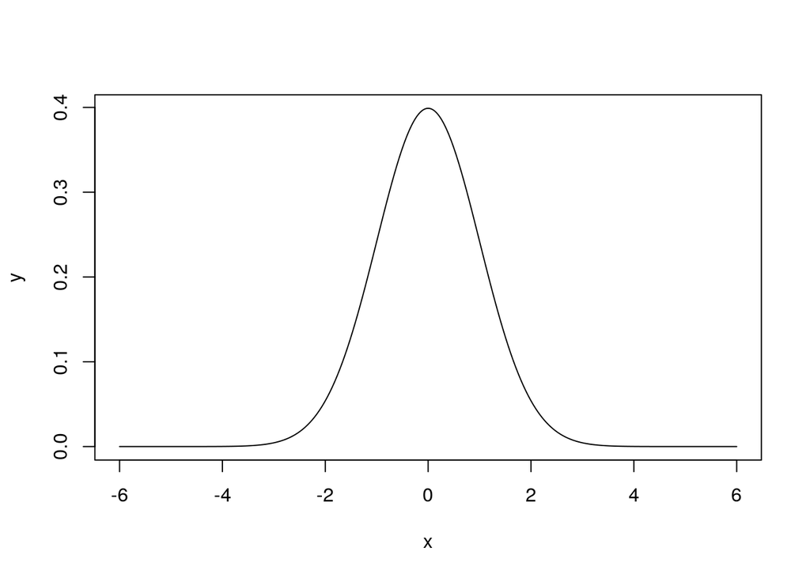

```r
x <- seq(-6, 6, by=0.01)
y <- dnorm(x)
plot(x, y, type="l")
```